# El motor de 4 tiempos

**1. Introducción al motor de 4 tiempos**

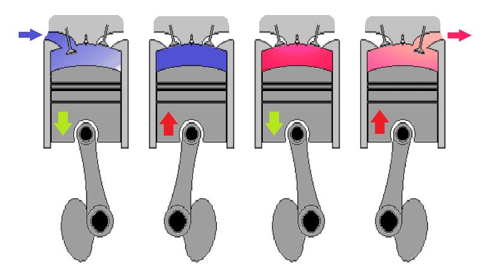

Motor 4T (actualidadmotor.com)

El motor de 4 tiempos es un motor de combustión interna muy usado actualmente. Puede funcionar con nafta o gasoil:

- **Nafta:** se caracteriza por el encendido de la mezcla aire-combustible mediante una bujía que produce una chispa.
- **Gasoil (diesel):** el encendido se produce solo por la alta compresión que se alcanza cuando el pistón sube.

Estos motores se usan en autos, camiones, motos, etc. En el ámbito agropecuario está en tractores, motobombas, generadores, etc.

El ciclo completo de este motor consta de 4 momentos que se corresponden con un movimiento hacia arriba o hacia abajo del pistón:

- **Admisión**: Entrada de mezcla aire-combustible (movimiento hacia abajo).
- **Compresión**: El pistón comprime la mezcla (movimiento hacia arriba).
- **Explosión** (o expansión): Se enciende la mezcla, genera energía (movimiento hacia abajo).
- **Escape**: Salida de gases quemados (movimiento hacia arriba).

### Actividad

**a)** Dibujar esquemáticamente los 4 momentos del motor poniendo especial cuidado en mostrar bien la posición de las válvulas. **b)** Mirar hasta comprender bien esta [animación](https://animatedengines.com/otto.html) de como funciona. Puedes regular la velocidad para verla más despacio. *Four strokes engine* significa motor de 4 tiempos en inglés. Responde esta prgunta: ¿De donde le viene el movimiento a las válvulas de admisión y escape, es decir de qué componentes del motor nace su movimiento? **c)** Completa el siguiente texto poniendo una sola palabra en cada línea: *Un motor de ____ tiempos realiza cuatro carreras del pistón para completar un ciclo: admisión, ____, explosión y ____. Un motor de ____ tiempos hace todo el ciclo en solo dos carreras, por lo que es más rápido pero suele desgastarse más y ____ más combustible. Los motores de 4T son más eficientes y duraderos.*

**2. Partes principales del motor**

En este caso se muestran las partes de un motor de nafta (encendido mediante bujía):

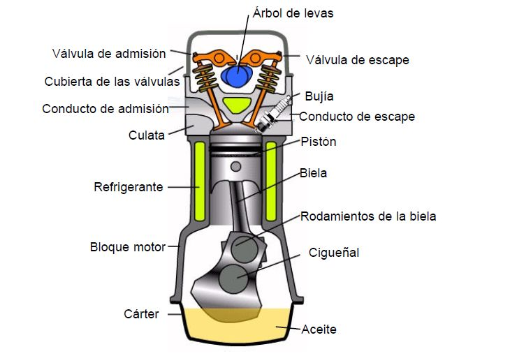

(i.pining.com)

### Actividad

**a)** Observa bien la imagen del punto anterior e intenta dibujarla, aunque no sea tan perfecta. Agrega flechas que unan los siguientes nombres con las partes correspondientes de tu dibujo: cilindro, pistón, biela, cigüeñal, válvula de admisión, válvula de escape, árbol de levas, bujía y cárter.

**b)** Haz esta actividad referida a motores 4T nafteros, también conocidos como motores Otto, en honor a su inventor, Nikolaus Otto.

- Abre este [link](https://www.liveworksheets.com/w/es/motores-de-combustion/1498413) y completa la actividad interactiva que aparece arrastrando los recuadros o escribiendo lo que corresponda. Al final cuando la hayas completado aprieta el botón **“Finish”** para que la página corrija tu trabajo.
- Escribe que errores tuviste y que palabras nuevas aprendiste

**3. Comparación entre el motor 2T y 4T**

Los motores de 4 tiempos (4T) y de 2 tiempos (2T) realizan la misma función: transformar la energía del combustible en movimiento. Sin embargo, lo hacen de manera diferente, lo que influye en su potencia, consumo de combustible, durabilidad, mantenimiento y aplicaciones más habituales. Comparar ambos tipos de motores permite comprender sus ventajas y desventajas.

### Actividad

Investiga y completa el siguiente cuadro comparativo entre los motores de 4T y 2T. Poner algo donde está cada línea “___“. En cada una puede haber una palabra o varias formando una frase según el caso.

| **Aspecto** | **Motor 4 tiempos (4T)** | **Motor 2 tiempos (2T)** |
| --- | --- | --- |
| **Número de carreras** | 4 | ___ |
| **Ciclo completo** | En ___ vueltas del cigüeñal | En ____ vuelta del cigüeñal |
| **Lubricación** | Por aceite en el ____ | Por aceite mezclado con el ____ |
| **Consumo de combustible** | ___ | ___ |
| **Durabilidad** | ___ | ___ |
| **Potencia por peso** | ___ | ___ |
| **Uso común** | Tractores, generadores, autos | Motosierra, motoguadañas, motos pequeñas |
| **Mantenimiento** | Menos frecuente, pero más complejo | Más frecuente, pero más simple |

**4. El sistema de distribución – Válvulas y árbol de levas**

El sistema de distribución permite que las **válvulas de admisión y escape se abran y cierren en el momento justo**, para que el ciclo funcione bien. Para esto:

- El **árbol de levas** tiene “levas” que empujan las válvulas.
- Está conectado al **cigüeñal** por una **correa o cadena**.
- Gira a **la mitad de la velocidad del cigüeñal** (por cada 2 vueltas del cigüeñal, el árbol de levas da 1).

El árbol de levas puede estar en distintas posiciones, aquí veremos solo cuando está arriba (a la cabeza) de los pistones.

Observa este [video](https://www.youtube.com/watch?v=3IGsxat0byE) para entender mejor esto.

### Actividad

**a)** Observa la figura y dibuja en forma simple el sistema de distribución con árbol de levas a la cabeza que se ve abajo. Investiga y agrega en tu dibujo los siguientes nombres a las flechas según corresponda:

- Árbol de levas (en mecánica se le dice árbol a todo eje que transmite giro)
- Leva
- Válvula
- Pistón
- Biela
- Cigueñal
- Correa de distibución
- Tensor de la correa

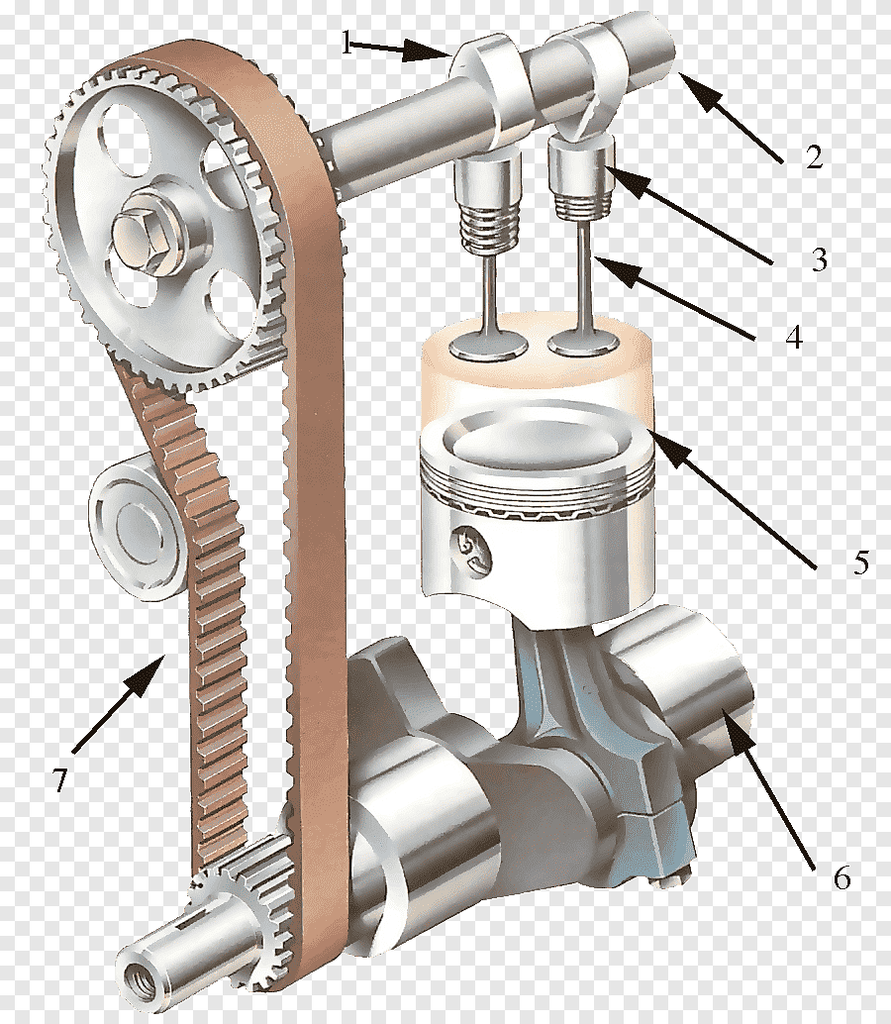

(gg.com)

**b)** Explica con tus palabras cómo se logra que las válvulas se abran y cierren a tiempo. Esta pregunta tienes, además, que saber explicarla oralmente.

**5. Lubricación – Cuidar las piezas internas**

En la hoja de tareas decía que había que hacer los puntos 7 y 8 de esta guía. Fue un error, hay que hacer las actividades de este punto 5 nomás.

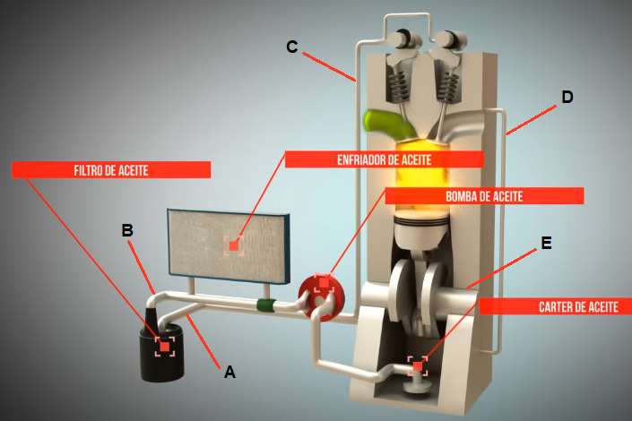

Sistema de lubricación típico

En un motor **4 tiempos**, el aceite reduce la fricción y el desgaste de las piezas móviles, además de ayudar a **refrigerar, limpiar y proteger contra la corrosión**.

Un sistema típico funciona así:

**Cárter → bomba de aceite → filtro → enfriador de aceite → conductos internos → piezas lubricadas → retorno al cárter**

La **bomba** impulsa el aceite desde el cárter hacia el motor. El aceite llega, entre otros lugares, a los **cojinetes del cigüeñal, biela, árbol de levas y tren de válvulas**. Luego, por gravedad, vuelve al cárter y el ciclo se repite.

### ¿Qué pasa con el aceite usado?

Con el funcionamiento, el aceite se contamina con **partículas metálicas, residuos de combustión, suciedad y productos de oxidación**. También pierde progresivamente parte de sus propiedades. Por eso debe **cambiarse periódicamente** y el aceite usado debe recolectarse y tratarse adecuadamente, **no arrojarse al suelo ni al desagüe**.

### Siglas y viscosidad del aceite

La **viscosidad** es la resistencia que presenta un líquido a fluir. Un aceite **más viscoso** fluye con mayor dificultad; uno **menos viscoso** fluye más fácilmente. Además, la viscosidad cambia con la temperatura: el aceite se vuelve más fluido cuando se calienta.

En Argentina se utiliza habitualmente la clasificación **SAE**, que significa **Society of Automotive Engineers** (Sociedad de Ingenieros Automotrices). La SAE clasifica los aceites principalmente según su **viscosidad**.

Por ejemplo, en un aceite **SAE 20W-40**:

- **20W**: indica su comportamiento de viscosidad a **bajas temperaturas**. La **W** significa *Winter* (invierno).
- **40**: indica su viscosidad a **alta temperatura**, aproximadamente la temperatura de funcionamiento del motor.

Se denomina **multigrado** porque un mismo aceite tiene una clasificación de viscosidad para **bajas temperaturas (20W)** y otra para **altas temperaturas (40)**. Esto permite que pueda fluir adecuadamente durante el arranque en frío y mantener una viscosidad apropiada cuando el motor está caliente. (Cuanto más alto es el número mayor es la viscocidad)

### Actividad

**1)** Busca el significado de “cojinete” y anótalo. Busca un video de menos de 4 minutos que esplique como funciona un cojinete y anota el título del video y el canal de youtube que lo contiene.

**2)** Observa este [video](https://www.youtube.com/watch?v=Cz-9lhSv5ZY). Luego une las letras A, B, C, D y E que aparecen en la figura inicial de este tema con las siguientes frases:

- Cojinete de cigueñal
- Conducto que lleva aceite al árbol de levas y válvulas
- Conducto de entrada al filtro de aceite
- Conducto de entrada al motor que se divide en dos
- Conducto de retorno de la zona del árbol de levas y válvulas al carter del motor

**3)** Explica con tus palabras que aceite usarías en un lugar con un clima muy frío (5W 40 o 20W 40) y porqué.

**4)** Consulta el manual de un motor real (auto, tractor, moto, etc.) (puede ser con ayuda de un adulto o técnico) y responde:

- ¿Qué aceite usa?
- ¿Cada cuántas horas (o Km) se cambia?

**6. Sistema de refrigeración – Evitar el sobrecalentamiento**

Observa este [video](https://www.youtube.com/watch?v=iDomoZkLoSs) para comprender mejor el sistema de enfriamiento de un motor.

Cuando el motor trabaja, genera calor por la explosión y la fricción. Para que no se dañe, debe mantenerse a una temperatura adecuada. Dependiendo del motor esta temperatura está entre 80 y 100°C.

**Formas de enfriar un motor**:

- **Refrigeración por aire**: utiliza aletas y, en algunos casos, un ventilador para disipar el calor hacia el ambiente. Es común en motocicletas, motoguadañas y otros motores pequeños.
- **Refrigeración por agua**: utiliza un líquido refrigerante que circula por el motor y transporta el calor hasta el radiador, donde se enfría. El sistema incluye, entre otros componentes, una bomba de agua, un termostato, un radiador y un ventilador.

### Actividad

**a)** Dibuja un esquema del sistema de enfriamiento como el de la figura de abajo. Pon atención a las flechas que muestran la circulación del agua. Al ir atravesando el motor el agua se va calentando y por eso las flechas se van poniento cada vez más rojas. Trata de dibujarlas siguiendo el color. Los nombres en la figura están en inglés pero tu pon los que aparecen en la siguiente lista en el lugar que les corresponda.

- Radiador
- Tapa del radiador
- Ventilador
- Termostato
- Bomba de agua

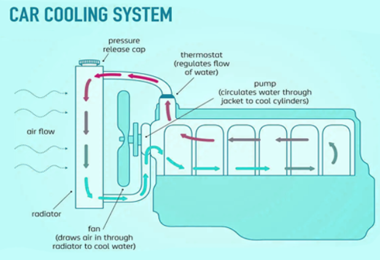

Sistema de refrigeración

**b)** Un termostato empieza a funcionar entre los 80 y 90°C. Explica con tus palabras que significa esto.

**c)** Observa el indicador de temperatura de la figura. Supón que la aguja empezó a pasar a la zona roja. *1)*¿Aqué temperatura empieza esta zona? *2)* ¿Qué es lo primero a revisar? *3)* Hacer un lista de otras cosas que pueden estar fallando.

[figure not shown]

**7. Arranque de un motor 4T**

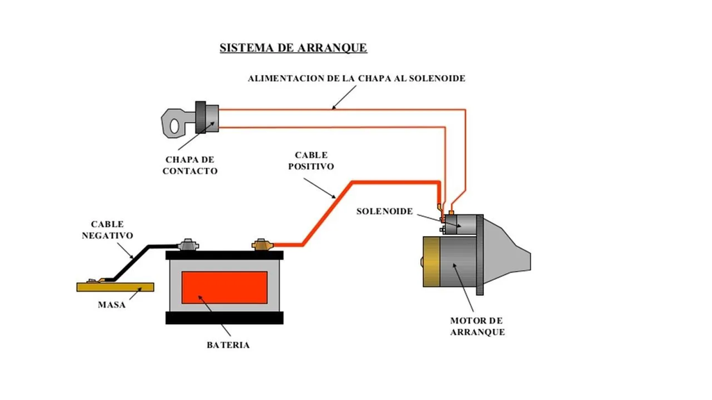

Al girar la llave la batería enciende el motor de arranque (Coches.com)

El arranque es el **momento inicial en el que el motor comienza a girar por sí mismo**, pasando de estar detenido a funcionar de forma continua.

Para cualquier motor de 4T, naftero o gasolero, el proceso de arranque es el siguiente:

1. Se gira la llave o se presiona el botón de encendido.
2. La batería envía electricidad al motor de arranque.
3. El motor de arranque hace girar el cigüeñal, lo que mueve los pistones.
4. El motor realiza los primeros ciclos. Una vez que uno de los cilindros genera combustión real, el motor empieza a girar solo.
5. El motor de arranque se desconecta automáticamente.

[Aquí](https://www.youtube.com/watch?v=hx5WVJQFuMk) puedes ver una explicación breve y gráfica.

### Actividad

Hacer un esquema del arranque de un motor 4T. Puede servirte de base la figura que aparece aquí o la que hicimos en clase. Tiene que aparecer como mínimo la llave de contacto, la batería y el motor de arranque.

**8. Encendido de un motor 4T**

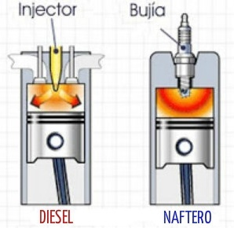

El naftero necesita chispa mientras que el gasolero se autoenciende por compresión

Una vez que el motor arranca hay que lograr que se mantenga en funcionamiento por sí mismo. Para ésto hay que lograr que la mezcla aire-combustible se encienda en un momento preciso dentro de cada cilindro. Este es el objetivo del **sistema de encendido** y funciona distinto según se trate de un motor naftero o gasolero (diesel).

### Encendido de un motor 4T naftero

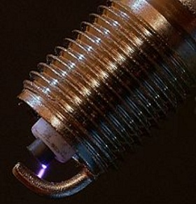

Chispa eléctrica en una bujía (Wikipedia)

Básicamente el motor naftero necesita de la chispa de la bujía para encender la mezcla de aire y combustible. Esta se produce gracias a la electricidad de alta tensión que llega a a la bujía en el momento justo. El momento justo es determinado por:

- **un distribuidor** mecánico en motores más antiguos,
- o por una computadora llamada **ECU** (Electronic control unit) en motores más modernos.

#### ¿Cómo es el sistema con distribuidor?

El distribuidor, usado en motores antiguos, es un dispositivo que:

- Gira con el motor.
- Abre y cierra un contacto llamado ruptor o “platino”.
- Manda corriente a la bujía correcta en el momento justo.
- Esta sincronizado con el cigüeñal.

Al ser un sistema mecánico es sensible al desgaste, la humedad y la suciedad.

#### ¿Cómo es el sistema con ECU?

Hoy en día, la mayoría de los vehículos usan un sistema totalmente electrónico, controlado por una ECU (Unidad de Control Electrónico).

**¿Qué es la ECU?**

La ECU es una computadora del motor. Controla muchas funciones, como:

- El encendido (cuándo generar la chispa en cada cilindro).
- La inyección de combustible.

La ECU recibe señales de sensores (por ejemplo, del cigüeñal y del árbol de levas) y decide:

- Qué bujía encender.
- En qué momento exacto hacerlo.

El sistema es más preciso, más confiable y requiere menos mantenimiento.

### Encendido en motor 4T gasolero (Diesel)

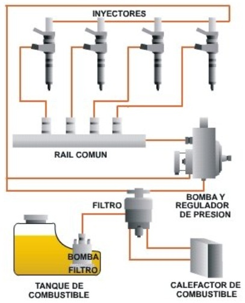

Sistema common rail (tecnologia-automovil.com)

Básicamente este motor no requiere ninguna chispa por que la mezcla aire-combustible se enciende sola al calentarse por la compresión. El combustible es inyectado por inyectores siendo el sistema “Common rail” uno muy común.

### Actividad

**a)** Piensa que en esta guía distinguimos “arranque” y “encendido”. Escribe, a la luz de lo que vimos, cuál es la diferencia entre ambos.

**b)** Busca un video breve que muestre como trabaja el sistema de encendido naftero por distribuidor y anota el nombre del video.

**c)** Expresa con tus palabras cual es la diferencia entre el encendido de un motor 4T naftero y uno gasolero.

**d)** Observa este [video](https://www.youtube.com/watch?v=qgTlBBWUM1Y) que muestra como funciona un sistema de inyección de combustible “Common rail” para motores gasolero (también puedes buscar otro que te parezca más claro). Luego escribe una explicación de como funciona este sistema asegurándote de usar las siguientes frases palabras en tu explicación: “common rail (riel común)”, “ECU”, “alta presión”, “inyectores”, “acelerador”.

**9. Tipos de mantenimiento**

El mantenimiento permite que el motor funcione correctamente, dure más y evite fallas graves. Hay básicamente rtes tipos:

### Mantenimiento preventivo

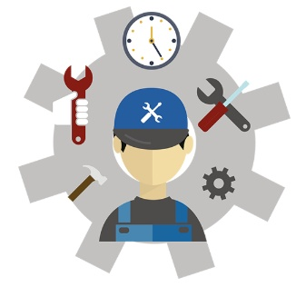

Se hace cada cierto tiempo o km (eribertodeolivera.com)

Son tareas que se hacen **antes de que algo falle**, para prolongar la vida útil del motor.

Ejemplos:

- **Cambio de aceite**: cada cierta cantidad de horas o kilómetros.
- **Limpieza o cambio del filtro de aire**.
- **Limpieza o cambio de bujía**.
- **Revisión de cables, tornillos, correas, mangueras**.
- **Revisión del sistema de refrigeración (nivel de agua o estado del radiador)**.
- **Ajuste de válvulas** (si aplica).
- **Chequeo de consumo de combustible**.

### Mantenimiento correctivo

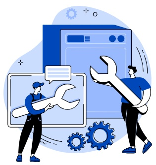

Se hace cuando algo ha fallado (rimsamex.com)

Se realiza **cuando algo ya está fallando**.

Ejemplos:

- Reemplazo de lámparas.
- Reparación del sistema de encendido, carburación o lubricación.
- Ajustes importantes cuando el motor pierde potencia, se traba o no arranca.

### Mantenimiento predictivo

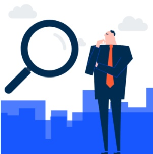

Implica observar, medir y predecir la falla (cegid.com)

Consiste en **anticipar fallas** observando o midiendo ciertos parámetros:

Ejemplo: Analizar muestras de aceite contándo partículas metálicas para medir el desgaste

### Actividades

**a)** Siempre es importante consultar el manual del vehículo o máquina en cuestión ya que da las pautas que son la base para hacer el mantenimiento. El manual más común es el **“manual del usuario”** que trae datos básicos. También está el **manual de taller o de servicio** que trae datos más especializados y es el que los mecánicos normalmente usan. Busca el manual de usuario de una maquina o vehículo con motor de 4T al que tengas acceso. Puede ser un grupo electrógeno, una moto, un auto, etc. Escribe un lista de al menos 5 mantenimientos preventivos que nombre el manual. Por ejemplo el manual puede decir en el caso de una moto: Lavar filtro de aire cada 3000 Km. A veces traen una tabla con un conjunto de cosas que hay que hacer cada cierto periodo.

**b)** Investiga en que consiste el mantenimiento preventivo llamado “regulación o ajuste de válvulas”. Busca algún video explicativo si quieres. Luego detalla **para que sirve** y **describe** brevemente el procedimiento.

**c)** Explica con tus palabras por que no harías mantenimiento preventivo con las lámparas de luz de un vehículo.